# TB PM Secondary Outcomes

Lauren Saag Peetluk

2020-11-23

```r
# Load datasets
load(file="/Users/Lauren/Box/RePORT Brazil/Datasets/Save/imputed_analysis_data.Rdata") # mi_sum dataset based on summarized imputation
load(file="/Users/Lauren/Box/RePORT Brazil/Datasets/Save/report_dissertation_lsp.Rdata") # original data with missing

# Load files from last run
# load(file="/Users/Lauren/Box/RePORT Brazil/Datasets/Save/tb_models_files")

# Load functions
source(here("functions.R"))

# Set data distribution
dd <- datadist (mi_sum)
options(datadist="dd")
```

```r
# Seed for all analyses
SEED = 1408

# Save outcome vector from mi_sum
outcome_vector <- mi_sum$unsuccessful

# RCS model formula
model_form_rcs <- as.formula(unsuccessful ~ hiv + diabetes_yn + rcs(lab_hgb,4) + evertb + xray_cavit + smear_pos + rcs(age,4) + female + rcs(bmi,4) + dishx_any_minus + rcs(educ_years,4) + alcoholhx + drughx + smokhx + non_white)
```

## Biologic outcomes (death, failure, regimen switch)

This analysis will exclude people who did not complete treatment or were LTF (not evaluated)

```r
biologic <- mi_sum %>% filter(outcome_cat!="Treatment incomplete" & outcome_cat!="Not evaluated")

biologic %>%
  tbl_cross(row=outcome_cat,
            col=unsuccessful,
            perc = "col")
```

| **Characteristic** | **unsuccessful** 0 | **unsuccessful** 1 | **Total** |  |
| --- | --- | --- | --- | --- |
| outcome_cat |  |  |  |  |
| Cure | 386 (51%) | 0 (0%) | 386 (47%) |  |
| Treatment complete | 367 (49%) | 0 (0%) | 367 (44%) |  |
| Death | 0 (0%) | 29 (40%) | 29 (3.5%) |  |
| Treatment failure | 0 (0%) | 29 (40%) | 29 (3.5%) |  |
| Regimen switch | 0 (0%) | 14 (19%) | 14 (1.7%) |  |
| Treatment incomplete | 0 (0%) | 0 (0%) | 0 (0%) |  |
| Not evaluated | 0 (0%) | 0 (0%) | 0 (0%) |  |
| Total | 753 (100%) | 72 (100%) | 825 (100%) |  |

```r
full_model_bio <- lrm(model_form_rcs, data=biologic, x=TRUE, y=TRUE)
anova(full_model_bio)
```

```
                Wald Statistics          Response: unsuccessful

 Factor          Chi-Square d.f. P
 hiv             12.37       1   0.0004
 diabetes_yn     10.31       1   0.0013
 lab_hgb         12.26       3   0.0066
  Nonlinear       0.76       2   0.6843
 evertb           3.82       1   0.0506
 xray_cavit       0.05       1   0.8259
 smear_pos        2.24       1   0.1341
 age              6.76       3   0.0800
  Nonlinear       4.27       2   0.1181
 female           0.11       1   0.7364
 bmi              5.82       3   0.1205
  Nonlinear       5.30       2   0.0707
 dishx_any_minus  0.89       1   0.3451
 educ_years       0.09       3   0.9930
  Nonlinear       0.05       2   0.9737
 alcoholhx        0.94       2   0.6255
 drughx           0.40       2   0.8175
 smokhx           0.26       2   0.8802
 non_white        0.73       1   0.3943
 TOTAL NONLINEAR  9.68       8   0.2882
 TOTAL           72.39      26   <.0001
```

BMI needs rcs - will use BMI categories

```r
biologic <- biologic %>%
  mutate(bmi_cat = case_when(
    bmi>=18.5 & bmi<25 ~ "Normal",
    bmi<18.5 ~ "Under",
    bmi>=25 ~ "Over",
    TRUE ~ NA_character_))

biologic %>%
  group_by(bmi_cat) %>%
  summarize(min_bmi = min(bmi),
            max_bmi = max(bmi))
```

| bmi_cat | min_bmi | max_bmi |
| --- | --- | --- |
| Normal | 18.5 | 25.0 |
| Over | 25.0 | 43.3 |
| Under | 12.4 | 18.5 |

```r
model_formula_bio <- as.formula(unsuccessful ~ hiv + diabetes_yn + lab_hgb + evertb + xray_cavit +
    smear_pos + age + female + bmi_cat + dishx_any_minus +
    educ_years + alcoholhx + drughx + smokhx + non_white)

approx_full_form_bio <- as.formula(predvals_full_model ~ hiv + diabetes_yn + lab_hgb + evertb +
    xray_cavit + smear_pos + age + female + bmi_cat + dishx_any_minus +
    educ_years + alcoholhx + drughx + smokhx + non_white)

set.seed(SEED)
seed=SEED

# Set data distribution
dd <- suppressWarnings(datadist(biologic))
options(datadist="dd")

save_results_biologic <- model_development(data=biologic,
                                  outcome=biologic$unsuccessful,
                                  model_formula=model_formula_bio,
                                  approx_full_formula=approx_full_form_bio,
                                  bootstraps=200,
                                  seed=SEED)
```

### Bootstrap resampling

The table below shows the model coefficients from the full model, the selected model, and the bootstrap resampled model. In addition it quantifies how often variables were included in 200 bootstrap samples and their RMSD. These are explained well in the tb_pm_development file.

```r
save_results_biologic$formatted_overview
```

|  | Global Model Estimate | Global Model Standard error | Selected Model Estimate | Selected Model Standard error | RMSD ratio | Bootstrap inclusion frequency (%) | Relative conditional bias (%) | Bootstrap Median | Bootstrap 2.5th percentile | Bootstrap 97.5% percentile |
| --- | --- | --- | --- | --- | --- | --- | --- | --- | --- | --- |
| (Intercept) | -1.686 | 1.305 | -0.957 | 0.949 | 1.100 | 100.0 | -24.95 | -1.366 | -3.689 | 1.530 |
| hiv | 1.182 | 0.338 | 1.220 | 0.311 | 1.062 | 98.5 | 3.66 | 1.208 | 0.553 | 1.891 |
| lab_hgb | -0.219 | 0.074 | -0.261 | 0.069 | 1.328 | 98.0 | 18.16 | -0.247 | -0.442 | -0.100 |
| diabetes_yn | 0.978 | 0.284 | 0.965 | 0.273 | 1.204 | 96.5 | 6.74 | 1.005 | 0.000 | 1.563 |
| evertb | -1.005 | 0.473 | -0.896 | 0.462 | 2.713 | 84.5 | 28.51 | -1.011 | -2.334 | 0.000 |
| age | 0.022 | 0.011 | 0.015 | 0.010 | 1.283 | 69.5 | 24.19 | 0.020 | 0.000 | 0.043 |
| smear_pos | 0.535 | 0.374 | 0.518 | 0.364 | 1.259 | 57.0 | 61.52 | 0.578 | 0.000 | 1.368 |
| bmi_catOver | -0.408 | 0.512 | 0.000 | 0.000 | 1.132 | 51.0 | 78.97 | 0.000 | -1.738 | 0.365 |
| bmi_catUnder | 0.405 | 0.305 | 0.000 | 0.000 | 1.267 | 51.0 | 46.58 | 0.000 | -0.094 | 0.989 |
| dishx_any_minus | -0.323 | 0.398 | 0.000 | 0.000 | 1.142 | 38.0 | 157.73 | 0.000 | -1.225 | 0.000 |
| alcoholhxFormer | -0.200 | 0.422 | 0.000 | 0.000 | 0.831 | 29.5 | 56.13 | 0.000 | -1.009 | 0.508 |
| alcoholhxCurrent | -0.389 | 0.451 | 0.000 | 0.000 | 1.031 | 29.5 | 111.76 | 0.000 | -1.337 | 0.000 |
| non_white | 0.256 | 0.382 | 0.000 | 0.000 | 1.139 | 28.0 | 193.67 | 0.000 | -0.013 | 1.190 |
| female | -0.077 | 0.306 | 0.000 | 0.000 | 1.002 | 26.0 | 331.08 | 0.000 | -0.785 | 0.546 |
| educ_years | -0.006 | 0.034 | 0.000 | 0.000 | 0.981 | 24.0 | 386.42 | 0.000 | -0.085 | 0.065 |
| smokhxFormer | 0.128 | 0.331 | 0.000 | 0.000 | 0.855 | 23.5 | 92.71 | 0.000 | -0.424 | 0.853 |
| smokhxCurrent | -0.243 | 0.435 | 0.000 | 0.000 | 0.870 | 23.5 | 155.67 | 0.000 | -1.162 | 0.159 |
| drughxFormer | 0.195 | 0.371 | 0.000 | 0.000 | 0.834 | 19.0 | 84.87 | 0.000 | -0.193 | 0.888 |
| drughxCurrent | 0.248 | 0.568 | 0.000 | 0.000 | 2.164 | 19.0 | -138.36 | 0.000 | -1.249 | 1.171 |
| xray_cavit | 0.003 | 0.294 | 0.000 | 0.000 | 0.874 | 18.0 | 1263.52 | 0.000 | -0.689 | 0.631 |

### Model coefficients

The table below compares the coefficients via the different methods for model selection. It is really just a simplification of the above table.

```r
save_results_biologic$coefficients_table
```

| variable | full_model | selected_model | coef_boot_median | coef_boot50_model | coef_shrink | approx_model |
| --- | --- | --- | --- | --- | --- | --- |
| Intercept | -1.68627 | -0.9569 | -1.3662 | -0.9569 | -0.8744 | -1.3186 |
| hiv | 1.18172 | 1.2195 | 1.2077 | 1.2195 | 1.1144 | 1.2680 |
| lab_hgb | -0.21901 | -0.2610 | -0.2474 | -0.2610 | -0.2385 | -0.2358 |
| diabetes_yn | 0.97766 | 0.9654 | 1.0047 | 0.9654 | 0.8822 | 0.9344 |
| evertb | -1.00491 | -0.8956 | -1.0112 | -0.8956 | -0.8184 | -0.9462 |
| age | 0.02167 | 0.0152 | 0.0203 | 0.0152 | 0.0139 | 0.0155 |
| smear_pos | 0.53534 | 0.5183 | 0.5783 | 0.5183 | 0.4736 | 0.5353 |
| bmi_catOver | -0.40760 | 0.0000 | 0.0000 | 0.0000 | 0.0000 | 0.0000 |
| bmi_catUnder | 0.40495 | 0.0000 | 0.0000 | 0.0000 | 0.0000 | 0.0000 |
| dishx_any_minus | -0.32280 | 0.0000 | 0.0000 | 0.0000 | 0.0000 | 0.0000 |

[output cut: 10 more lines]

### Model performance

```r
save_results_biologic$models_performance
```

| stat | V1 | V2 | V3 | V4 | V5 |
| --- | --- | --- | --- | --- | --- |
| model | full_model | selected_model | boot50_model | shrink | approx |
| brier_score | 0.0706 | 0.0714 | 0.0714 | 0.0720 | 0.0720 |
| cal_slope | 1.00 | 1.00 | 1.00 | 1.09 | 1.02 |
| cal_int | 0.000 | 0.000 | 0.000 | 0.000 | 0.108 |
| c_ci | 0.79 (0.73, 0.84) | 0.78 (0.73, 0.83) | 0.78 (0.72, 0.83) | 0.78 (0.73, 0.83) | 0.78 (0.73, 0.83) |

### Internal validation

Here are the estimated c-statisitcs from the full model and the model including only variables that were selected in at least 50% of the bootstrap resamples.

```r
save_results_biologic$c_statistics
```

```
$full_model
                 2.5% 97.5%
orig      0.789 0.736 0.838
corrected 0.729 0.676 0.783

$boot50_model
                 2.5% 97.5%
orig      0.778 0.725 0.828
corrected 0.758 0.705 0.811
```

### Calibration

Below is the calibration plot from the model developed using the variables that were selected in at least 50% of the bootstrap resamples.

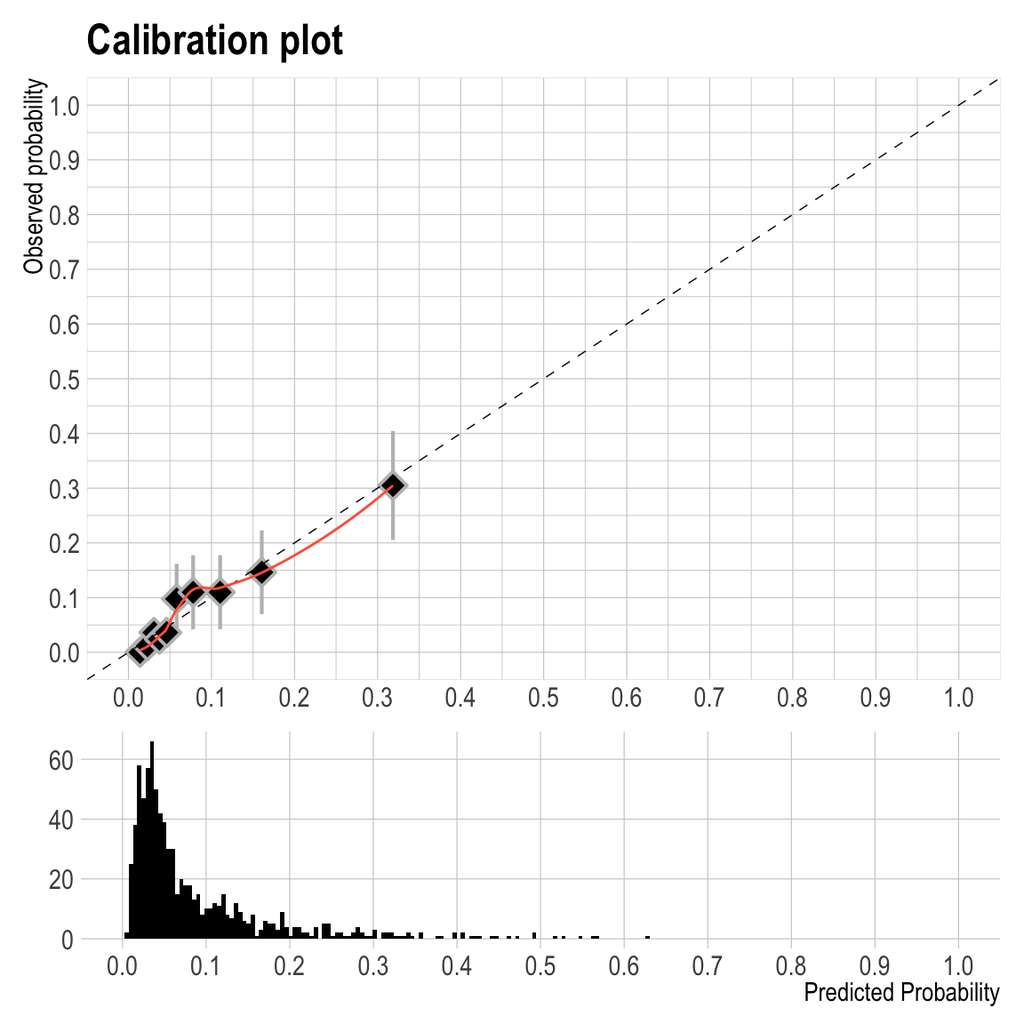

```r
save_results_biologic$boot50_calibration
```

### Model approximation

The boot50 model approximates the predicted values from the full model with an R2 of:

```r
save_results_biologic$r2_approx
```

```
   R2
0.891
```

### ROC curve

This is the ROC curve based on the predicted values from the boot50 model, but shrunk by the heuristic shrinkage factor to account for overfitting.

```r
save_results_biologic$roc_shrink
```

```
Call:
roc.data.frame(data = data, response = outcome, predictor = predrisk_shrink,     ci = TRUE)

Data: predrisk_shrink in 753 controls (outcome 0) < 72 cases (outcome 1).
Area under the curve: 0.778
95% CI: 0.727-0.829 (DeLong)
```

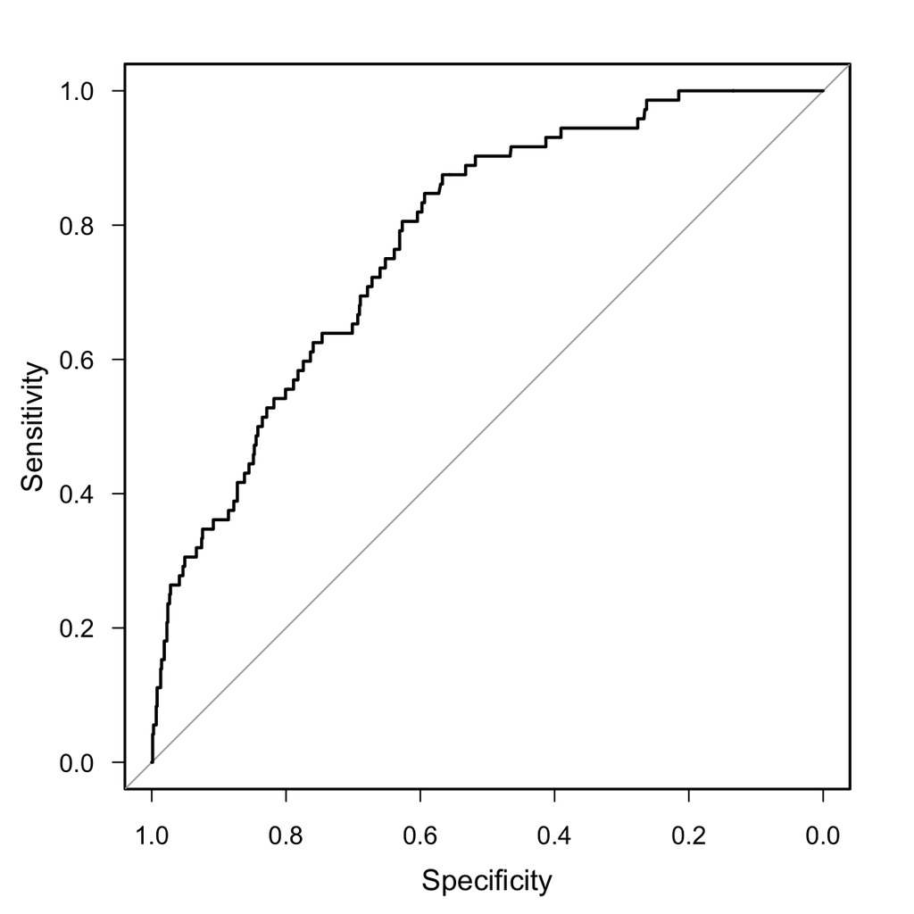

```r
plot(save_results_biologic$roc_shrink)
```

The AUC from that model is consistent with the AUC from the boot50 model.

### Boot medians

As a refresher, here are the coefficients from that procedure:

```r
# Boot50 medians
boot_medians_bio <- save_results_biologic$raw_overview[,"boot_median"][which(save_results_biologic$raw_overview[,"boot_median"]!=0)]
names_boot_medians_bio <- names(boot_medians_bio)

boot_medians_bio
```

```
[1] -1.3662  1.2077 -0.2474  1.0047 -1.0112  0.0203  0.5783
```

```r
mi_sum <- mi_sum %>%
  mutate(predvals_boot_median_bio =
           -0.442 +
           1.167*hiv +
           1.044*diabetes_yn +
           -0.245*lab_hgb +
           -0.880*evertb +
           0.019*age +
           0.593*smear_pos,
         predrisk_boot_median_bio = 1/(1+exp(-predvals_boot_median_bio))
         )

mi_sum %>%
  select(predvals_boot_median_bio, predrisk_boot_median_bio, unsuccessful) %>%
  tbl_summary(by="unsuccessful")
```

| **Characteristic** | **0**, N = 753<sup>1</sup> | **1**, N = 191<sup>1</sup> |
| --- | --- | --- |
| predvals_boot_median_bio | -2.06 (-2.59, -1.26) | -1.42 (-2.20, -0.53) |
| predrisk_boot_median_bio | 0.11 (0.07, 0.22) | 0.19 (0.10, 0.37) |

<sup>*1*</sup> Statistics presented: median (IQR)

#### Performance

Brier score, calibration slope, and calibration intercept of the full model:

```r
boot_med_bio_perf <- ev_glm(method="original", lp="predvals_boot_median_bio", outcome="unsuccessful", data=mi_sum, samples=200, return="performance")

brier <- boot_med_bio_perf["Brier", "apparent"]
slope <- boot_med_bio_perf["Slope", "apparent"]
intercept <- boot_med_bio_perf["Intercept", "apparent"]

perf_boot_median_bio <- rbind("Brier score" = brier, "Calibration slope" = slope, "Calibration intercept" = intercept)
perf_boot_median_bio
```

```
                        [,1]
Brier score            0.156
Calibration slope      0.533
Calibration intercept -0.489
```

CI for apparent c-statistic

```r
predvals_boot_median_bio = mi_sum$predvals_boot_median_bio

c_boot_median_bio <- c_ci(predvals_boot_median_bio, outcome_vector)
c_boot_median_bio
```

```
     c_stat    LB    UB
[1,]  0.644 0.597 0.686
```

#### Calibration plot

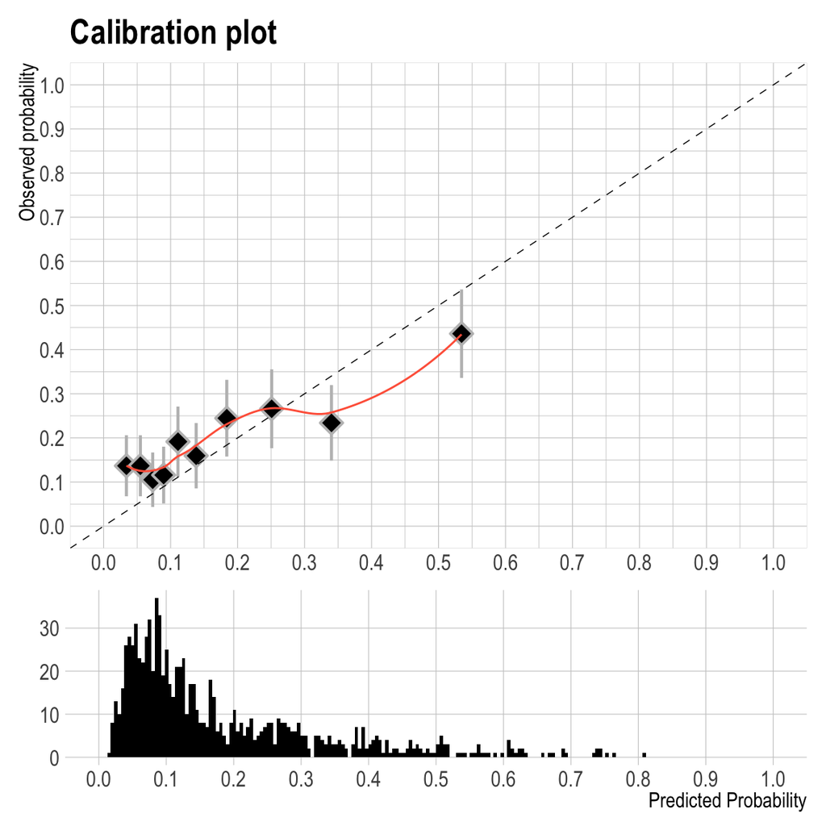

```r
cal_plot_solo(mi_sum, predvals_boot_median_bio, outcome_vector)
```

#### ROC curve

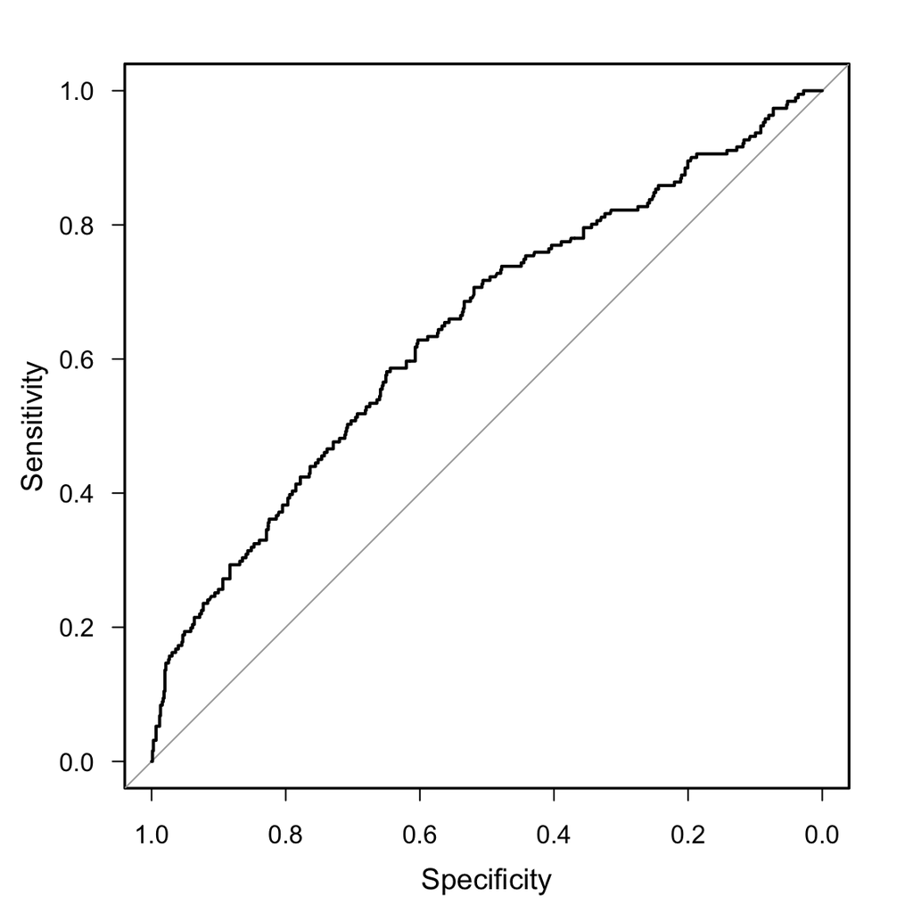

```r
plot(ev_glm(method="original", lp="predvals_boot_median_bio", outcome="unsuccessful", data=mi_sum, samples=1, return="roc"))
```

## Behavioral outcomes (treatment incomplete, not evaluated)

```r
behavioral <- mi_sum %>% filter(outcome_cat!="Death" & outcome_cat!="Treatment failure" & outcome_cat!="Regimen switch")

behavioral %>%
  tbl_cross(row=outcome_cat,
            col=unsuccessful,
            perc = "col")
```

| **Characteristic** | **unsuccessful** 0 | **unsuccessful** 1 | **Total** |  |
| --- | --- | --- | --- | --- |
| outcome_cat |  |  |  |  |
| Cure | 386 (51%) | 0 (0%) | 386 (44%) |  |
| Treatment complete | 367 (49%) | 0 (0%) | 367 (42%) |  |
| Death | 0 (0%) | 0 (0%) | 0 (0%) |  |
| Treatment failure | 0 (0%) | 0 (0%) | 0 (0%) |  |
| Regimen switch | 0 (0%) | 0 (0%) | 0 (0%) |  |
| Treatment incomplete | 0 (0%) | 56 (47%) | 56 (6.4%) |  |
| Not evaluated | 0 (0%) | 63 (53%) | 63 (7.2%) |  |
| Total | 753 (100%) | 119 (100%) | 872 (100%) |  |

```r
full_model_behav <- lrm(model_form_rcs, data=behavioral, x=TRUE, y=TRUE)
anova(full_model_behav)
```

```
                Wald Statistics          Response: unsuccessful

 Factor          Chi-Square d.f. P
 hiv               1.58      1   0.2083
 diabetes_yn       2.38      1   0.1225
 lab_hgb           4.42      3   0.2193
  Nonlinear        0.19      2   0.9085
 evertb            0.14      1   0.7054
 xray_cavit        0.07      1   0.7925
 smear_pos         0.57      1   0.4487
 age              13.23      3   0.0042
  Nonlinear        2.32      2   0.3138
 female            2.96      1   0.0855
 bmi               3.75      3   0.2900
  Nonlinear        1.59      2   0.4512
 dishx_any_minus   0.29      1   0.5932
 educ_years       13.75      3   0.0033
  Nonlinear        2.05      2   0.3582
 alcoholhx         2.83      2   0.2425
 drughx           12.72      2   0.0017
 smokhx            9.65      2   0.0080
 non_white         1.03      1   0.3104
 TOTAL NONLINEAR   5.81      8   0.6681
 TOTAL           107.09     26   <.0001
```

No non-linear terms are needed

```r
model_formula_behav <- as.formula(unsuccessful ~ hiv + diabetes_yn + lab_hgb + evertb + xray_cavit +
    smear_pos + age + female + bmi + dishx_any_minus +
    educ_years + alcoholhx + drughx + smokhx + non_white)

approx_full_form_behav <- as.formula(predvals_full_model ~ hiv + diabetes_yn + lab_hgb + evertb +
    xray_cavit + smear_pos + age + female + bmi + dishx_any_minus +
    educ_years + alcoholhx + drughx + smokhx + non_white)


set.seed(SEED)
seed=SEED

# Set data distribution
dd <- suppressWarnings(datadist(behavioral))
options(datadist="dd")

save_results_behavioral <- model_development(data=behavioral,
                                  outcome=behavioral$unsuccessful,
                                  model_formula=model_formula_behav,
                                  approx_full_formula=approx_full_form_behav,
                                  bootstraps=200,
                                  seed=SEED)
```

### Bootstrap resampling

The table below shows the model coefficients from the full model, the selected model, and the bootstrap resampled model. In addition it quantifies how often variables were inclued in 200 bootstrap resamples and their RMSD. These are explained well in the tb_pm_development file.

```r
save_results_behavioral$formatted_overview
```

|  | Global Model Estimate | Global Model Standard error | Selected Model Estimate | Selected Model Standard error | RMSD ratio | Bootstrap inclusion frequency (%) | Relative conditional bias (%) | Bootstrap Median | Bootstrap 2.5th percentile | Bootstrap 97.5% percentile |
| --- | --- | --- | --- | --- | --- | --- | --- | --- | --- | --- |
| (Intercept) | 0.904 | 1.183 | 1.954 | 1.000 | 1.371 | 100.0 | -2.35 | 0.925 | -2.656 | 4.043 |
| educ_years | -0.106 | 0.031 | -0.104 | 0.031 | 1.171 | 97.5 | 4.83 | -0.110 | -0.174 | -0.046 |
| drughxFormer | 0.453 | 0.296 | 0.524 | 0.293 | 1.167 | 97.5 | 17.48 | 0.490 | -0.033 | 1.273 |
| drughxCurrent | 1.202 | 0.325 | 1.350 | 0.315 | 1.324 | 97.5 | 13.19 | 1.333 | 0.612 | 2.072 |
| age | -0.037 | 0.011 | -0.036 | 0.010 | 1.271 | 96.5 | 4.84 | -0.037 | -0.061 | 0.000 |
| smokhxFormer | 0.991 | 0.319 | 1.099 | 0.304 | 1.219 | 96.5 | 12.01 | 1.085 | 0.000 | 1.778 |
| smokhxCurrent | 0.869 | 0.330 | 1.028 | 0.320 | 1.313 | 96.5 | 17.38 | 0.968 | 0.000 | 1.854 |
| lab_hgb | -0.120 | 0.061 | -0.140 | 0.056 | 1.377 | 74.5 | 35.57 | -0.134 | -0.264 | 0.000 |
| female | -0.512 | 0.280 | -0.576 | 0.277 | 1.269 | 71.0 | 35.98 | -0.578 | -1.128 | 0.000 |
| bmi | -0.065 | 0.038 | -0.055 | 0.037 | 1.425 | 60.5 | 46.19 | -0.062 | -0.172 | 0.000 |
| diabetes_yn | 0.439 | 0.275 | 0.449 | 0.271 | 1.285 | 58.5 | 44.10 | 0.456 | 0.000 | 0.960 |
| hiv | 0.336 | 0.297 | 0.000 | 0.000 | 1.194 | 47.0 | 92.11 | 0.000 | 0.000 | 0.968 |
| alcoholhxFormer | 0.629 | 0.541 | 0.000 | 0.000 | 1.214 | 45.5 | 64.80 | 0.000 | 0.000 | 1.948 |
| alcoholhxCurrent | 0.821 | 0.528 | 0.000 | 0.000 | 1.424 | 45.5 | 58.21 | 0.000 | 0.000 | 2.208 |
| non_white | 0.310 | 0.335 | 0.000 | 0.000 | 1.217 | 38.5 | 135.50 | 0.000 | 0.000 | 1.168 |
| smear_pos | 0.228 | 0.307 | 0.000 | 0.000 | 1.036 | 28.0 | 164.06 | 0.000 | 0.000 | 0.868 |
| dishx_any_minus | -0.109 | 0.378 | 0.000 | 0.000 | 1.042 | 21.0 | 533.46 | 0.000 | -1.139 | 0.584 |
| evertb | 0.142 | 0.298 | 0.000 | 0.000 | 0.852 | 19.5 | 107.61 | 0.000 | -0.533 | 0.632 |
| xray_cavit | -0.045 | 0.237 | 0.000 | 0.000 | 0.969 | 18.5 | 274.47 | 0.000 | -0.570 | 0.476 |

### Model coefficients

The table below compares the coefficients via the different methods for model selection. It is really just a simplication of the above table.

```r
save_results_behavioral$coefficients_table
```

| variable | full_model | selected_model | coef_boot_median | coef_boot50_model | coef_shrink | approx_model |
| --- | --- | --- | --- | --- | --- | --- |
| Intercept | 0.9043 | 1.9545 | 0.9246 | 1.9545 | 1.8103 | 2.0693 |
| educ_years | -0.1058 | -0.1041 | -0.1103 | -0.1041 | -0.0964 | -0.1087 |
| drughxFormer | 0.4529 | 0.5245 | 0.4904 | 0.5245 | 0.4858 | 0.5470 |
| drughxCurrent | 1.2022 | 1.3499 | 1.3329 | 1.3499 | 1.2503 | 1.3667 |
| age | -0.0368 | -0.0356 | -0.0369 | -0.0356 | -0.0330 | -0.0375 |
| smokhxFormer | 0.9908 | 1.0991 | 1.0852 | 1.0991 | 1.0180 | 1.1148 |
| smokhxCurrent | 0.8685 | 1.0275 | 0.9680 | 1.0275 | 0.9517 | 1.0634 |
| lab_hgb | -0.1195 | -0.1402 | -0.1335 | -0.1402 | -0.1299 | -0.1429 |
| female | -0.5121 | -0.5755 | -0.5779 | -0.5755 | -0.5330 | -0.6490 |
| bmi | -0.0646 | -0.0548 | -0.0618 | -0.0548 | -0.0508 | -0.0562 |

[output cut: 9 more lines]

### Model performance

```r
save_results_behavioral$models_performance
```

| stat | V1 | V2 | V3 | V4 | V5 |
| --- | --- | --- | --- | --- | --- |
| model | full_model | selected_model | boot50_model | shrink | approx |
| brier_score | 0.0983 | 0.0987 | 0.0987 | 0.0990 | 0.0990 |
| cal_slope | 1.000 | 1.000 | 1.000 | 1.080 | 0.968 |
| cal_int | 0.000 | 0.000 | 0.000 | 0.000 | -0.026 |
| c_ci | 0.82 (0.79, 0.86) | 0.82 (0.78, 0.85) | 0.82 (0.78, 0.85) | 0.82 (0.78, 0.85) | 0.82 (0.78, 0.85) |

### Internal validation

Here are the estimated c-statistics from the full model and the model including only variables that were selected in at least 50% of the bootstrap resamples:

```r
save_results_behavioral$c_statistics
```

```
$full_model
                 2.5% 97.5%
orig      0.824 0.787 0.858
corrected 0.792 0.756 0.827

$boot50_model
                 2.5% 97.5%
orig      0.817 0.781 0.854
corrected 0.798 0.762 0.837
```

### Calibration

Below is the calibration plot from the model developed using the variables that were selected in at least 50% of the bootstrap resamples.

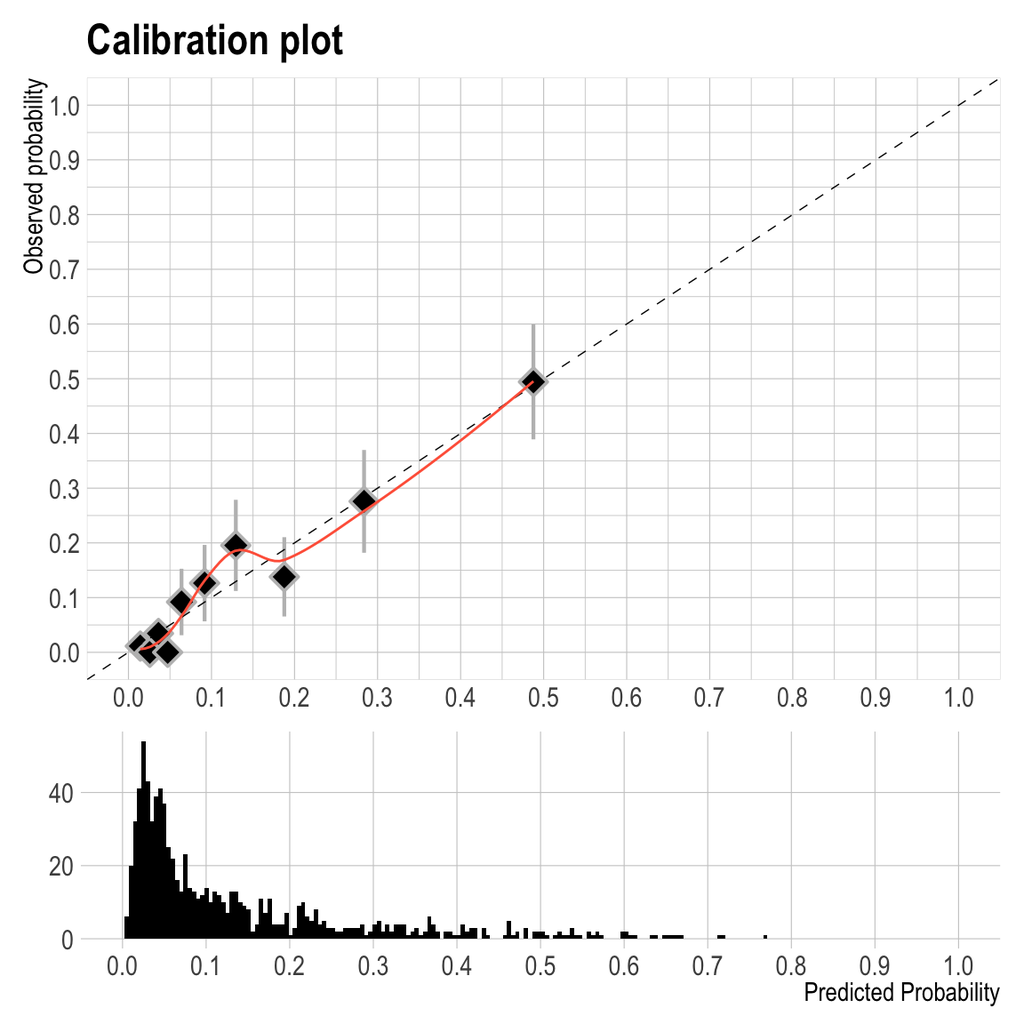

```r
save_results_behavioral$boot50_calibration
```

### Model approximation

The boot50 model approximates the predicted values from the full model with an R2 of:

```r
save_results_behavioral$r2_approx
```

```
   R2
0.934
```

### ROC Curve

This is the ROC curve based on the predicted values from the boot50 model, but shrunk by the heuristic shrinkage factor to account for overfitting.

```r
save_results_behavioral$roc_shrink
```

```
Call:
roc.data.frame(data = data, response = outcome, predictor = predrisk_shrink,     ci = TRUE)

Data: predrisk_shrink in 753 controls (outcome 0) < 119 cases (outcome 1).
Area under the curve: 0.817
95% CI: 0.78-0.854 (DeLong)
```

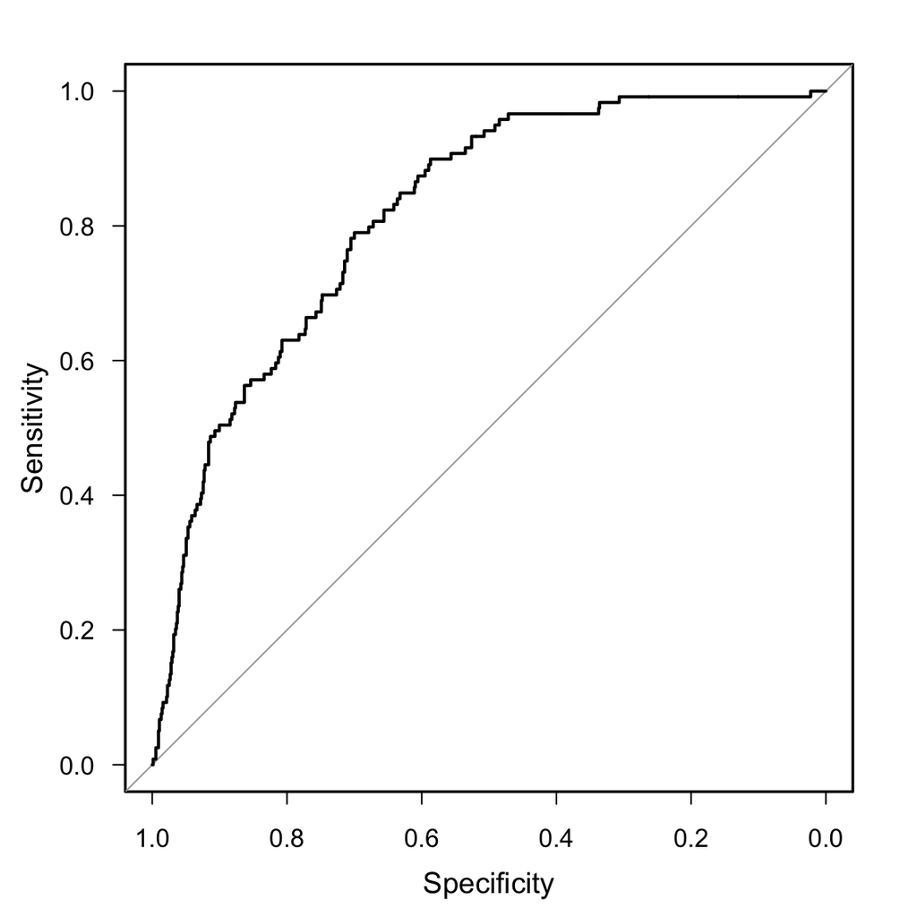

```r
plot(save_results_behavioral$roc_shrink)
```

### Boot medians

As a refresher, here are the coefficients from that procedure:

```r
# Boot50 medians
boot_medians_behav <- save_results_behavioral$raw_overview[,"boot_median"][which(save_results_behavioral$raw_overview[,"boot_median"]!=0)]
names_boot_medians_behav <- names(boot_medians_behav)

boot_medians_behav
```

```
 [1]  0.9246 -0.1103  0.4904  1.3329 -0.0369  1.0852  0.9680 -0.1335 -0.5779
[10] -0.0618  0.4563
```

```r
mi_sum <- mi_sum %>%
  mutate(predvals_boot_median_behav =
          0.870 +
           -0.116*educ_years +
           -0.039*age +
           1.248*(drughx=="Current") +
           0.491*(drughx=="Former") +
           0.969*(smokhx=="Current") +
           1.065*(smokhx=="Former")+
           -0.121*lab_hgb +
           -0.505*female +
           -0.065*bmi +
           0.397*hiv +
           0.402*diabetes_yn +
           0.032*(alcoholhx=="Current"),
         predrisk_boot_median_behav = 1/(1+exp(-predvals_boot_median_behav))
         )

mi_sum %>%
  select(predvals_boot_median_behav, predrisk_boot_median_behav, unsuccessful) %>%
  tbl_summary(by="unsuccessful")
```

| **Characteristic** | **0**, N = 753<sup>1</sup> | **1**, N = 191<sup>1</sup> |
| --- | --- | --- |
| predvals_boot_median_behav | -3.94 (-4.66, -3.04) | -2.72 (-3.65, -1.74) |
| predrisk_boot_median_behav | 0.02 (0.01, 0.05) | 0.06 (0.03, 0.15) |

<sup>*1*</sup> Statistics presented: median (IQR)

#### Performance

Brier score, calibration slope, and calibration intercept of the full model:

```r
boot_med_behav_perf <- ev_glm(method="original", lp="predvals_boot_median_behav", outcome="unsuccessful", data=mi_sum, samples=200, return="performance")

brier <- boot_med_behav_perf["Brier", "apparent"]
slope <- boot_med_behav_perf["Slope", "apparent"]
intercept <- boot_med_behav_perf["Intercept", "apparent"]

perf_boot_median_behav <- rbind("Brier score" = brier, "Calibration slope" = slope, "Calibration intercept" = intercept)
perf_boot_median_behav
```

```
                       [,1]
Brier score           0.170
Calibration slope     0.699
Calibration intercept 0.916
```

CI for apparent c-statistic

```r
predvals_boot_median_behav = mi_sum$predvals_boot_median_behav

c_boot_median_behav <- c_ci(predvals_boot_median_behav, outcome_vector)
c_boot_median_behav
```

```
     c_stat    LB    UB
[1,]  0.736 0.697 0.773
```

#### Calibration plot

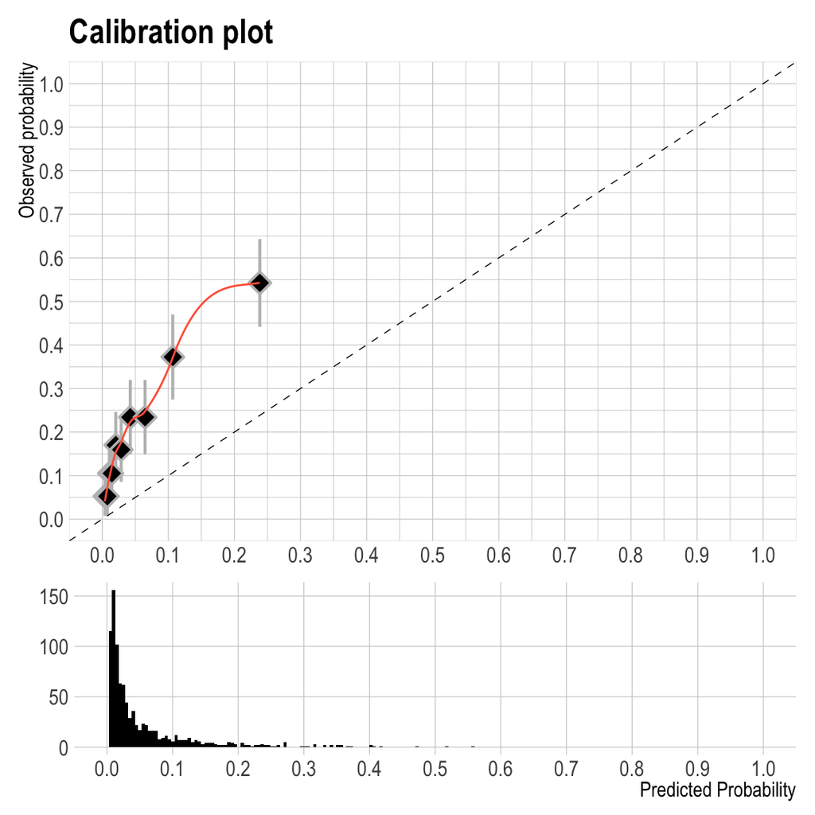

```r
cal_plot_solo(mi_sum, predvals_boot_median_behav, outcome_vector)
```

#### ROC curve

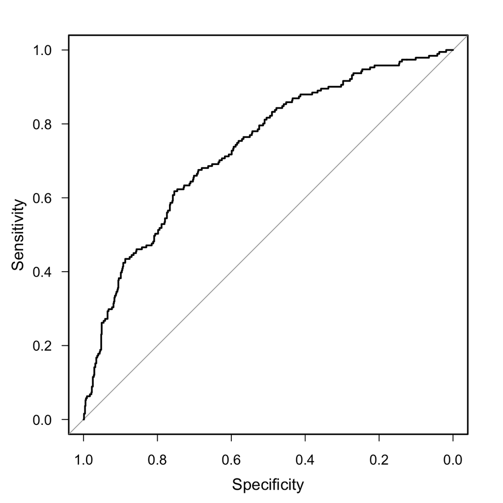

```r
plot(ev_glm(method="original", lp="predvals_boot_median_behav", outcome="unsuccessful", data=mi_sum, samples=1, return="roc"))
```

```r
save.image(file="/Users/Lauren/Box/RePORT Brazil/Datasets/Save/tb_models_files")
```

```r
# Save results to excel


# Biologic outcomes results
bio_overview <- save_results_biologic$raw_overview
bio_coefficients <- save_results_biologic$coefficients_table
bio_performance <- save_results_biologic$models_performance

# Behavioral outcomes results
behav_overview <- save_results_behavioral$raw_overview
behav_coefficients <- save_results_behavioral$coefficients_table
behav_performance <- save_results_behavioral$models_performance


# ---- Save to Excel ---

library(openxlsx)

# Create a blank workbook
other_outcomes <- createWorkbook()

# Add some sheets to the workbook
addWorksheet(other_outcomes, "Biologic-Model-Selection")
addWorksheet(other_outcomes, "Biologic-Coefficients")
addWorksheet(other_outcomes, "Biologic-Performance")
addWorksheet(other_outcomes, "Behavioral-Model-Selection")
addWorksheet(other_outcomes, "Behavioral-Coefficients")
addWorksheet(other_outcomes, "Behavioral-Performance")


# Write the data to the sheets
writeData(other_outcomes, sheet = "Biologic-Model-Selection", x = bio_overview)
writeData(other_outcomes, sheet = "Biologic-Coefficients", x = bio_coefficients)
writeData(other_outcomes, sheet = "Biologic-Performance", x = bio_performance)
writeData(other_outcomes, sheet = "Behavioral-Model-Selection", x = behav_overview)
writeData(other_outcomes, sheet = "Behavioral-Coefficients", x = behav_coefficients)
writeData(other_outcomes, sheet = "Behavioral-Performance", x = behav_performance)

# Export the file
saveWorkbook(other_outcomes, here("Manuscript", "tables", "other_outcomes_results.xlsx"), overwrite=TRUE)
```